# GSS Challenge Less Data

Tyler Hamblin

29 September 2023

# Introduction

Is attitude toward capitol punishment (cappun) independent of race (race)? If not, then whose view differs from whom??

$H_A$: A change in race statistically results in a change in opinion towards capitol punishment.

$H_0$: The two factors race and cappun have no affect on each other.

```r
mydata <- mydata %>%
mutate(across(where(is.character), as.factor))
```

# Methods

By looking at the data in this project we can see that the data is Categorical~Categorical meaning that we will use the Cat_Cat helper file from the CandP zip. We will run commands for a bar chart to graphically express the data and a table to show the numerical version. Finally under the inferential data section a Chi-Squared test will tell us if there is a statistical difference or not but not where the difference is. For that we will rely on a FisherXY test which runs the fisher test in a loop for a multitude of combinations.

# Results

## Descriptive Results

### Graphical Descriptive Results

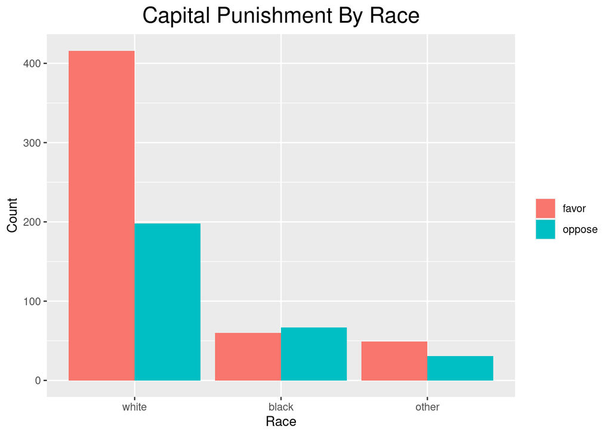

```r
ggplot(mydata, aes(x = race, fill = cappun)) +
  geom_bar(position = "dodge") +
  labs(title = "Capital Punishment By Race",
       x = "Race",
       y = "Count") +
  theme(legend.title = element_blank(),
        plot.title = element_text(hjust = 0.5,size = 18))
```

Again we see the same disproportionate ammount of white peopel in favor of capitol punishment. Black people in this data set still are slightly more opposed to the use of it.

### Numerical Descriptive Results

```r
table1 <- xtabs(~race + cappun, data=mydata)
rowPerc(table1)
```

```
##        cappun
## race     favor oppose  Total
##   white  67.75  32.25 100.00
##   black  47.24  52.76 100.00
##   other  61.25  38.75 100.00
```

```r
colPerc(table1)
```

```
##        cappun
## race     favor oppose
##   white  79.24  66.89
##   black  11.43  22.64
##   other   9.33  10.47
##   Total 100.00 100.00
```

## Inferential Results

```r
chisq.test(table1)
```

```
##
##  Pearson's Chi-squared test
##
## data:  table1
## X-squared = 19.477, df = 2, p-value = 5.896e-05
```

```r
chisqtestGC(table1)
```

```
## Pearson's Chi-squared test
##
## Observed Counts:
##        cappun
## race    favor oppose
##   white   416    198
##   black    60     67
##   other    49     31
##
## Counts Expected by Null:
##        cappun
## race     favor oppose
##   white 392.63 221.37
##   black  81.21  45.79
##   other  51.16  28.84
##
## Contributions to the chi-square statistic:
##        cappun
## race    favor oppose
##   white  1.39   2.47
##   black  5.54   9.83
##   other  0.09   0.16
##
##
## Chi-Square Statistic = 19.4773
## Degrees of Freedom of the table = 2
## P-Value = 1e-04
```

From the Chi-Squared test we see that the Statistic is still much higher than the critical value provided by the degrees of freedom. The large number shows there is a difference from the expected value and a small p-value shows statistical variation as well. A fisher test needs to be ran in order to find out where the difference occurs amongst the data.

```r
FisherTable(table1,confL = 0.95,printAll = TRUE)
```

[output not shown]

```r
sub_whiteBlack <- mydata %>% filter(race %in% c("white", "black"))
sub_whiteBlack$race <- factor(sub_whiteBlack$race, levels = c("white", "black") )
table2 <- xtabs(~cappun + race, data=sub_whiteBlack)
fisherResult <- fisher.test(table2)
fisherResult
```

```
##
##  Fisher's Exact Test for Count Data
##
## data:  table2
## p-value = 1.741e-05
## alternative hypothesis: true odds ratio is not equal to 1
## 95 percent confidence interval:
##  1.562325 3.521989
## sample estimates:
## odds ratio
##   2.343236
```

```r
low=(fisherResult$conf.int[1]/(fisherResult$conf.int[1] + 1))*100
hi=(fisherResult$conf.int[2]/(fisherResult$conf.int[2] + 1))*100
print("Confidence Interval")
```

```
## [1] "Confidence Interval"
```

```r
low
```

```
## [1] 60.97294
```

```r
hi
```

```
## [1] 77.88584
```

# Discussion and Conclusion

We have shown that the white race still has a higher incidence of being in favor of capitol punishment compared to the two other groups even when in a smaller sample size. This was done within the graphical and numerical sections and allows us to reject $H_0$ and verify $H_A$. This circumstance does not clarify any social or environmental factors that also may differ between the large and small sample sizes so we can not confirm why the data is slightly varied. It may also be natural variation falling within the margin of error.